# Data Manipulation and Visualization in R for NICU Data

Zachary Vesoulis

2025-02-21

## Overview

This R Markdown document is part of the pre-conference workshop “Artificial Intelligence in Critical Care Medicine” presented at the 41st Annual CNH Symposium

*License: GPL-3.0*

## Setup

First, we’ll load the required packages for data visualization. If they aren’t already installed on your system, this code will handle the installation.

```r
# List of required packages
required_packages <- c("ggplot2", "gridExtra", "fst")

# Function to install missing packages
install_if_missing <- function(packages) {
  missing_packages <- packages[!(packages %in% installed.packages()[,"Package"])]
  if (length(missing_packages) > 0) {
    message("Installing missing packages: ", paste(missing_packages, collapse = ", "))
    install.packages(missing_packages)
  }
}

# Install missing packages
install_if_missing(required_packages)

# Load the required packages
library(ggplot2)
library(gridExtra)
library(fst)

# Set knitr options
knitr::opts_chunk$set(echo = TRUE)
```

## Data Loading

This tutorial uses data from the UVA dataverse library, specifically from Niestroy et al.’s study: “Discovery of signatures of fatal neonatal illness in vital signs using highly comparative time-series analysis” (https://doi.org/10.18130/V3/VJXODP).

```r
# Load the modified version of NICU_1007_vitals.mat
library(fst)
newTable <- read_fst("/Users/vesoulis_z/Downloads/pas_workshop2023-main/code/newTable.fst")
```

## Initial Data Visualization

Since R cannot efficiently plot the entire dataset, we’ll create a smaller subset covering 96 hours (172,801 samples).

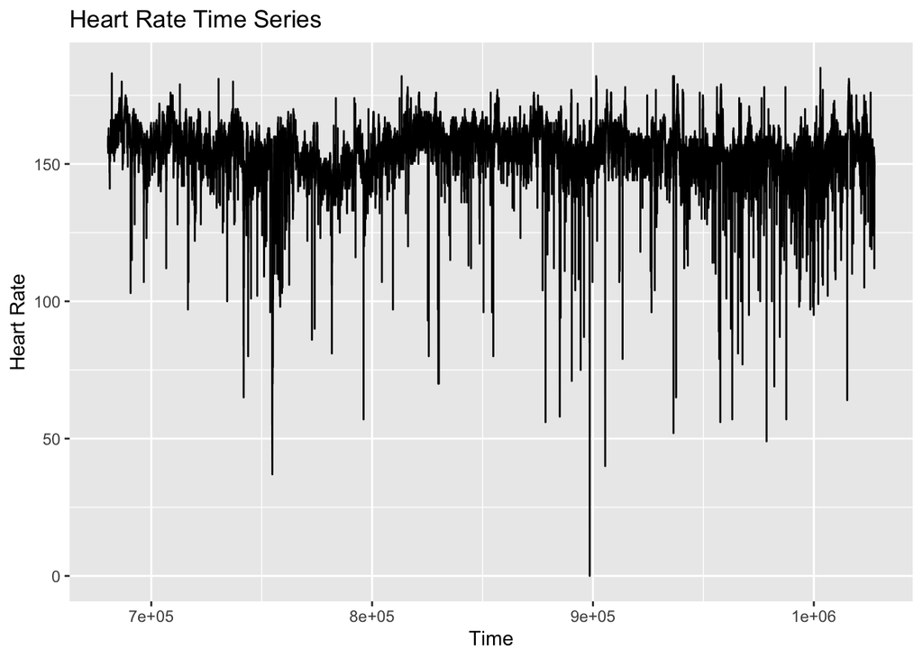

```r
# Create subset
f <- newTable[300000:472800, ]

# Basic time series plot
ggplot(f, aes(x=TIME, y=HR)) +
  geom_line() +
  labs(title="Heart Rate Time Series",
       x="Time",
       y="Heart Rate")
```

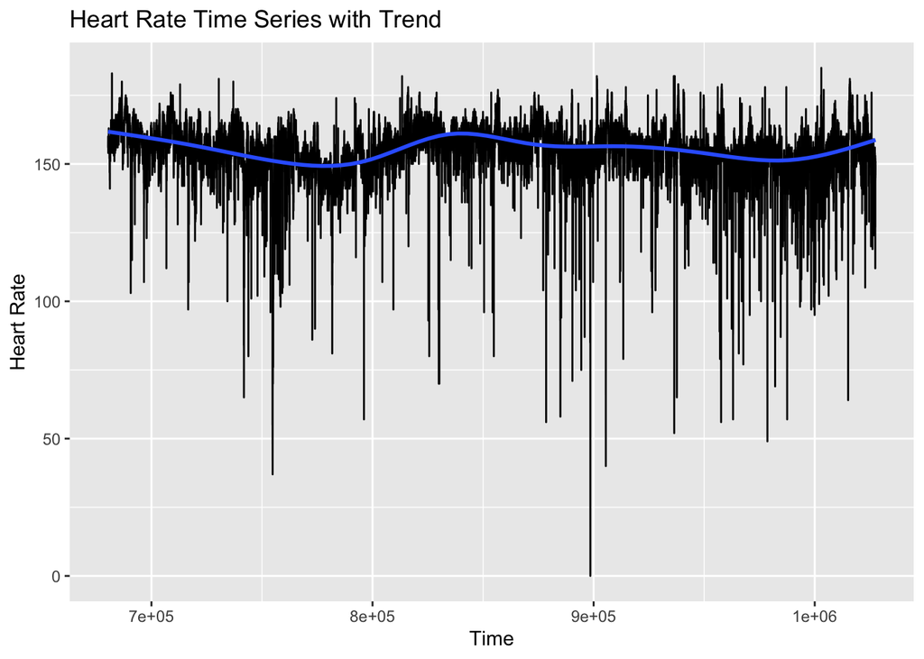

```r
# Add trend line using GAM
ggplot(f, aes(x=TIME, y=HR)) +
  geom_line() +
  stat_smooth() +
  labs(title="Heart Rate Time Series with Trend",
       x="Time",
       y="Heart Rate")
```

## SpO2 Distribution Analysis

We’ll analyze SpO2 distributions at three distinct periods in the patient’s life. This infant was born at 24 weeks gestation, with recording starting at approximately 1.8 days of life.

```r
# Create time period subsets
# 24 hours at 2.6 days old (24 weeks PMA)
time1 <- newTable[17000:60200, ]

# 24 hours at 71 days old (34 weeks PMA)
time2 <- newTable[1490000:1533200, ]

# 24 hours at 285 days old (64 weeks PMA)
time3 <- newTable[6100000:6143200, ]
```

### Basic Histograms

First, let’s look at basic histograms for each time period.

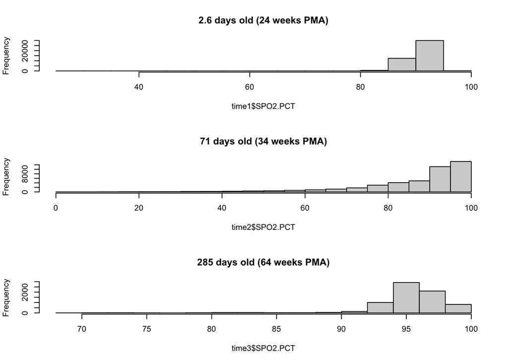

```r
par(mfrow=c(3,1))
hist(time1$SPO2.PCT, main="2.6 days old (24 weeks PMA)")
hist(time2$SPO2.PCT, main="71 days old (34 weeks PMA)")
hist(time3$SPO2.PCT, main="285 days old (64 weeks PMA)")
```

### Enhanced Visualization using ggplot

Now, let’s create more polished histograms with consistent axes and styling.

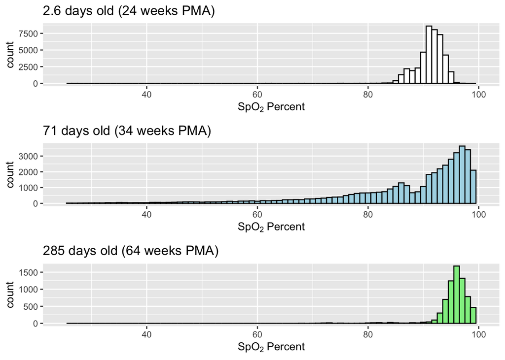

```r
# Create individual plots
p1 <- ggplot(time1, aes(x=SPO2.PCT)) +
  geom_histogram(color="black", fill="white", binwidth = 1) +
  xlim(25,100) +
  ggtitle("2.6 days old (24 weeks PMA)") +
  xlab(expression(SpO[2]~Percent))

p2 <- ggplot(time2, aes(x=SPO2.PCT)) +
  geom_histogram(color="black", fill="lightblue", binwidth = 1) +
  xlim(25,100) +
  ggtitle("71 days old (34 weeks PMA)") +
  xlab(expression(SpO[2]~Percent))

p3 <- ggplot(time3, aes(x=SPO2.PCT)) +
  geom_histogram(color="black", fill="lightgreen", binwidth = 1) +
  xlim(25,100) +
  ggtitle("285 days old (64 weeks PMA)") +
  xlab(expression(SpO[2]~Percent))

# Arrange plots in a grid
grid.arrange(p1, p2, p3, nrow = 3)
```

### Kernel Density Plots

Finally, let’s create a kernel density plot that overlays all three distributions. This requires the data to be in long format, with an additional column for the time period.

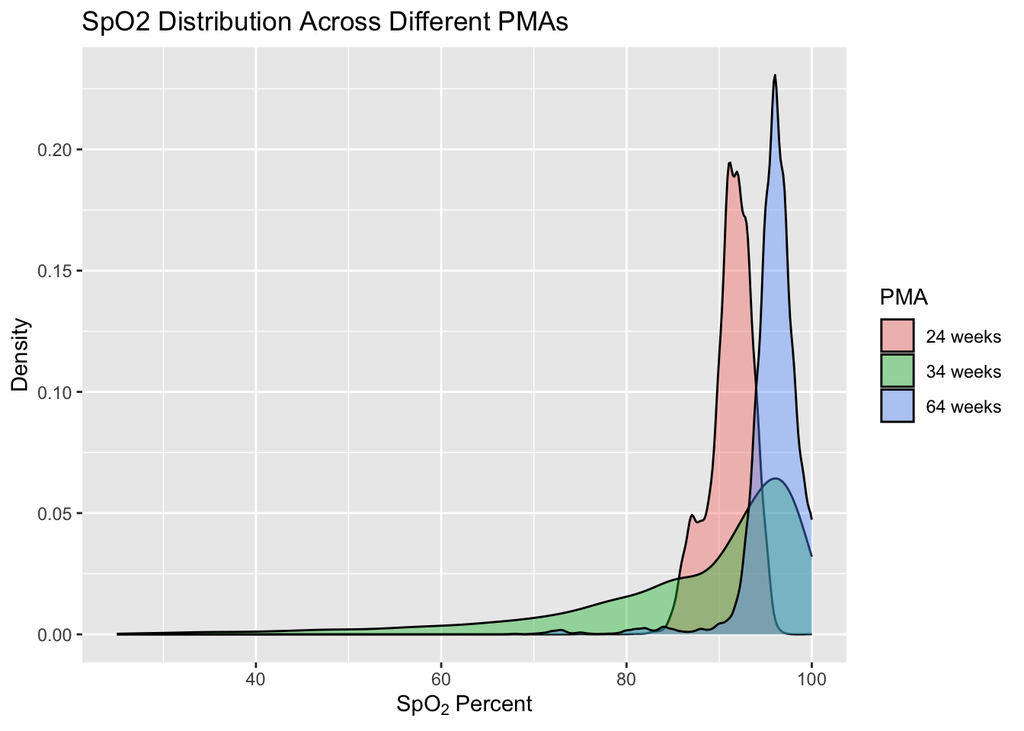

```r
# Load the pre-prepared long format data
df_long <- readRDS("df_long.rds")

# Create density plot
ggplot(df_long, aes(SPO2.PCT, fill=period)) +
  geom_density(adjust=2, alpha=0.4) +
  xlim(25,100) +
  guides(fill=guide_legend(title="PMA")) +
  scale_fill_discrete(labels=c('24 weeks','34 weeks','64 weeks')) +
  xlab(expression(SpO[2]~Percent)) +
  labs(title="SpO2 Distribution Across Different PMAs",
       y="Density")
```